# Overview

**Project:** Promoter Opening

**Author:** Vivek

**Generated:** Sun Sep 27 2020, 09:03 PM

## Overview

- Define late induced genes
- GO analysis of late genes
- Seperate late genes to groups by pol II occupancy in different tissues
- RNA-seq expression
- Promoter element enrichments
- ImaGO terms
- Gene length
- ATAC 14-17h
- MNase 2-4h and 14-17hrs

## Late induced genes and housekeeping genes

Whole-embryo wild-type 2-4h (Nina) and 14-17h (Malini) were processed with `kallisto` and compared with `DESeq2`.

```
 gene_group       count   median_TPM
```

Housekeeping genes 662 30.3

## Late-induced genes 1530 27.75

Table: Summary of late-induced genes

```
##                                          wt_14to14.5h_1
## "../fastq/rnaseq/kallisto//wt_14to14.5h_1/abundance.h5"
##                                          wt_14to14.5h_2
## "../fastq/rnaseq/kallisto//wt_14to14.5h_2/abundance.h5"
##                                          wt_17to17.5h_1
## "../fastq/rnaseq/kallisto//wt_17to17.5h_1/abundance.h5"
##                                          wt_17to17.5h_2
## "../fastq/rnaseq/kallisto//wt_17to17.5h_2/abundance.h5"
```

```
## 1 2 3 4
```

## GO analysis

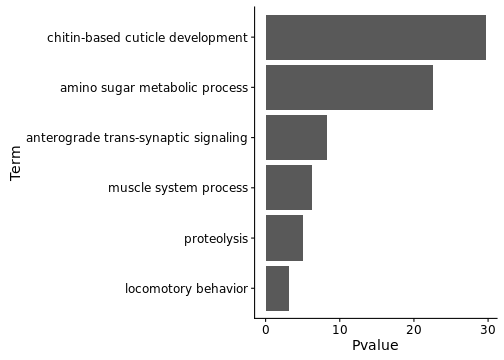

## Dividing genes by Pol II presence in different tissues

Next, we will calculate Pol II enrichment levels at the promoters of all genes and divide the late-induced genes into groups based on the number of tissues where Pol II is detected at least 2-fold above background. We will use the following Pol II samples:

```
label       factor   median_enrichment   max_enrichment
```

early_embryo polii 0.04969 6.941

embryo14 polii 0.4641 6.819

epidermis polii 0.3205 6.134

```
 glia       polii          0.334             5.632

 gut        polii         0.4288              6.03

muscle      polii         0.6466             6.124

neuron      polii         0.4475             6.204
```

## trachea polii 0.2465 5.236

Table: Summary of Pol II enrichments (log2)

Using a threshold of 2-fold enrichment over input, we can divide the late-induced genes by the number of tissues where Pol II is detected:

Tissues count

```
0       527

1       268

2       147

3       119

4       103

5       115

6       247
```

Table: Late-induced genes

We will also define fewer groups by combining some of the above groups:

Tissues count

0 tissues 527

1-2 tissues 415

3-4 tissues 222

## 5-6 tissues 362

Table: Alternate groups for late-induced genes

## Sigalova and Bjoern groups

## RNA-seq expression

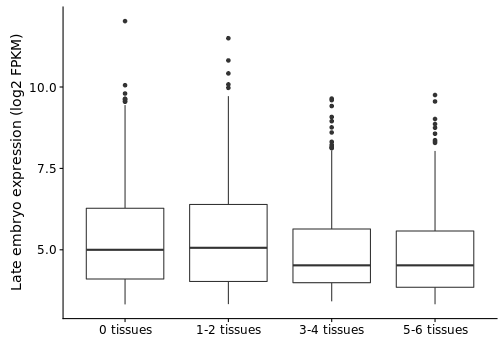

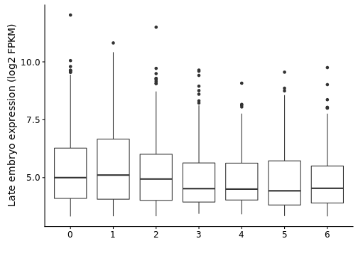

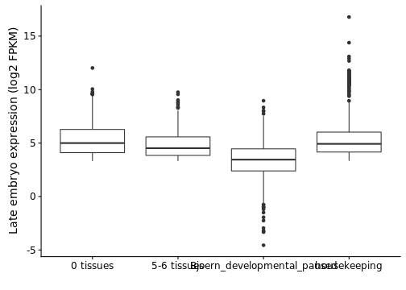

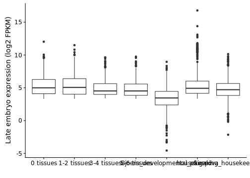

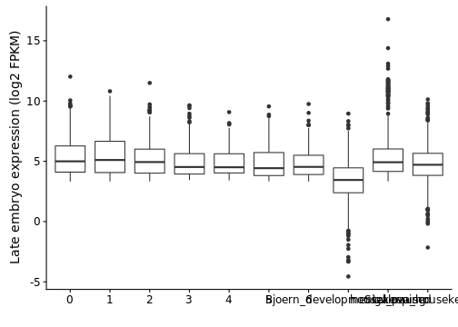

```
##
##  Wilcoxon rank sum test with continuity correction
##
## data:  exp.df %>% filter(group_name == test_group_1) %>% dplyr::select(variable) %>%  and exp.df %>% filter(group_name == test_group_2) %>% dplyr::select(variable) %>%     as.matrix and     as.matrix
## W = 112270, p-value = 7.196e-06
## alternative hypothesis: true location shift is not equal to 0
```

```
##
##  Wilcoxon rank sum test with continuity correction
##
## data:  exp.df %>% filter(group_name == test_group_1) %>% dplyr::select(variable) %>%  and exp.df %>% filter(group_name == test_group_2) %>% dplyr::select(variable) %>%     as.matrix and     as.matrix
## W = 69678, p-value = 8.214e-12
## alternative hypothesis: true location shift is not equal to 0
```

```
##
##  Wilcoxon rank sum test with continuity correction
##
## data:  exp.df %>% filter(group_name == test_group_1) %>% dplyr::select(variable) %>%  and exp.df %>% filter(group_name == test_group_2) %>% dplyr::select(variable) %>%     as.matrix and     as.matrix
## W = 119420, p-value = 1.656e-10
## alternative hypothesis: true location shift is not equal to 0
```

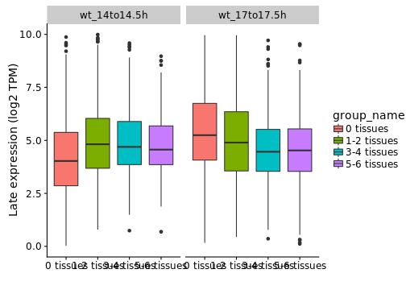

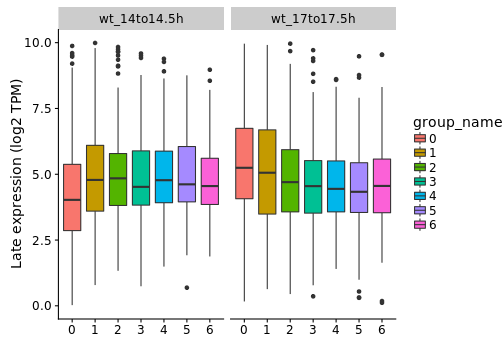

## Promoter element enrichments

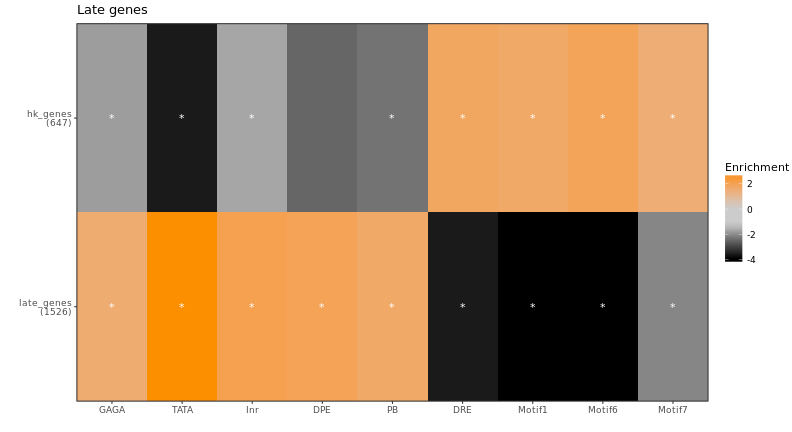

## Promoter element enrichments

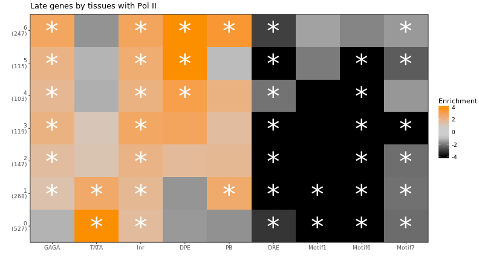

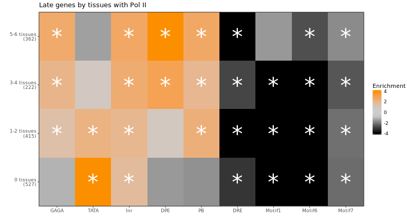

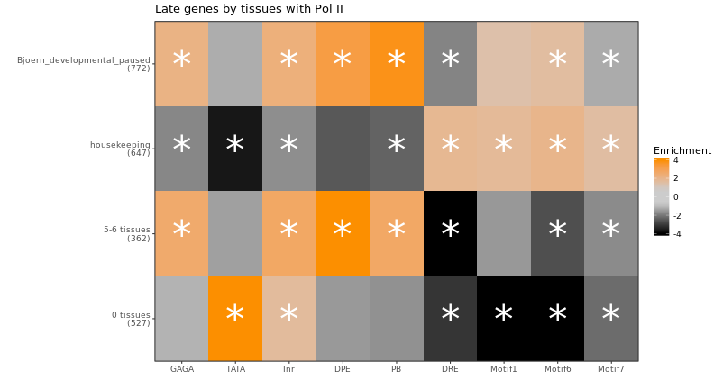

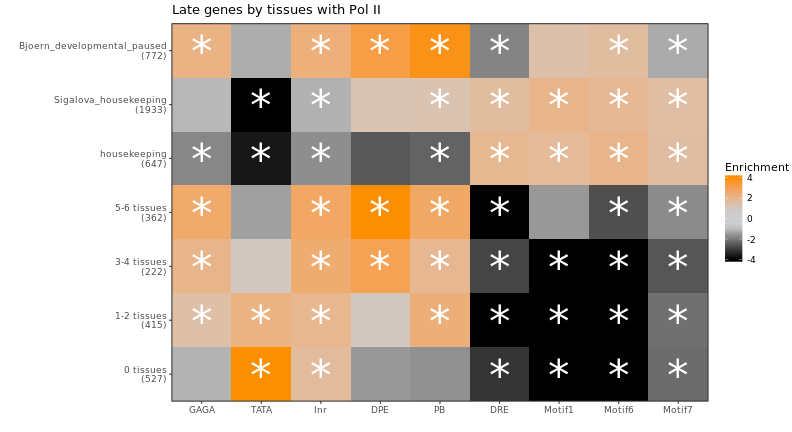

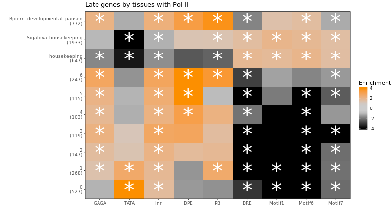

## ImaGO terms

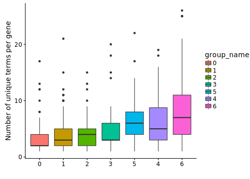

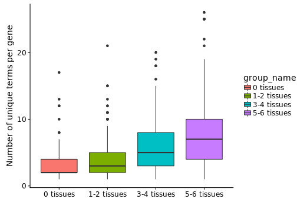

```
##
##  Wilcoxon rank sum test with continuity correction
##
## data:  counts.df %>% filter(group_name == test_group_1) %>% dplyr::select(variable) %>%  and counts.df %>% filter(group_name == test_group_2) %>% dplyr::select(variable) %>%     as.matrix and     as.matrix
## W = 3460.5, p-value < 2.2e-16
## alternative hypothesis: true location shift is not equal to 0
```

```
##
##  Wilcoxon rank sum test with continuity correction
##
## data:  counts.df %>% filter(group_name == test_group_1) %>% dplyr::select(variable) %>%  and counts.df %>% filter(group_name == test_group_2) %>% dplyr::select(variable) %>%     as.matrix and     as.matrix
## W = 5337, p-value < 2.2e-16
## alternative hypothesis: true location shift is not equal to 0
```

## Gene length

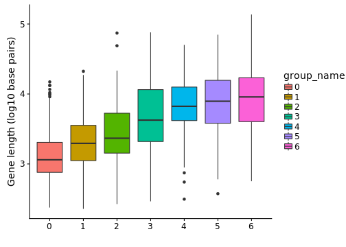

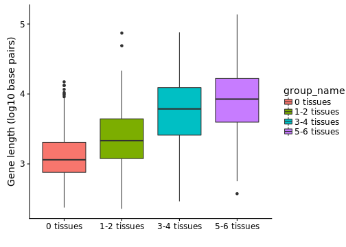

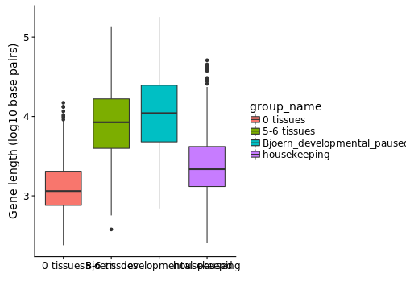

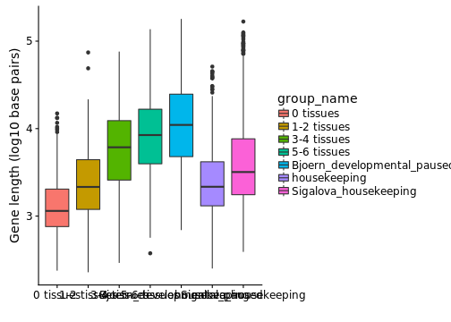

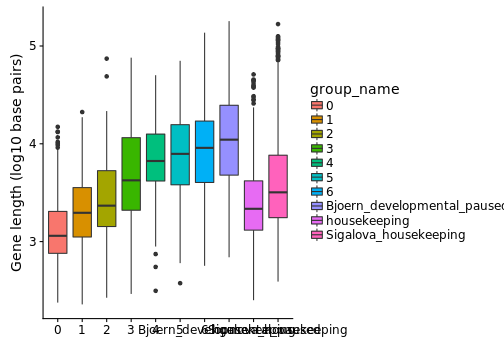

```
##
##  Wilcoxon rank sum test with continuity correction
##
## data:  filter(., group_name == test_group_1) %>% dplyr::select(variable) %>%  and filter(., group_name == test_group_2) %>% dplyr::select(variable) %>%     as.matrix and     as.matrix
## W = 10258, p-value < 2.2e-16
## alternative hypothesis: true location shift is not equal to 0
```

```
##
##  Wilcoxon rank sum test with continuity correction
##
## data:  filter(., group_name == test_group_1) %>% dplyr::select(variable) %>%  and filter(., group_name == test_group_2) %>% dplyr::select(variable) %>%     as.matrix and     as.matrix
## W = 15528, p-value < 2.2e-16
## alternative hypothesis: true location shift is not equal to 0
```

## Go analysis tata and highly paused genes

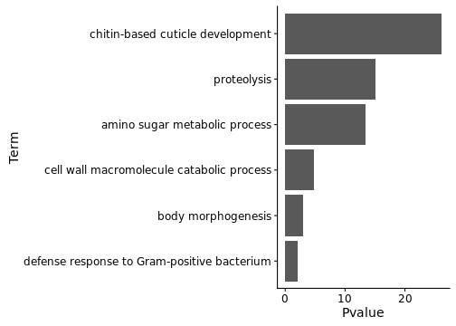

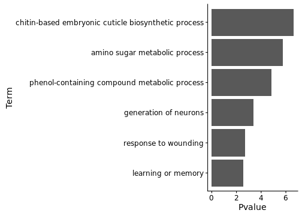

## ATAC 14-17h

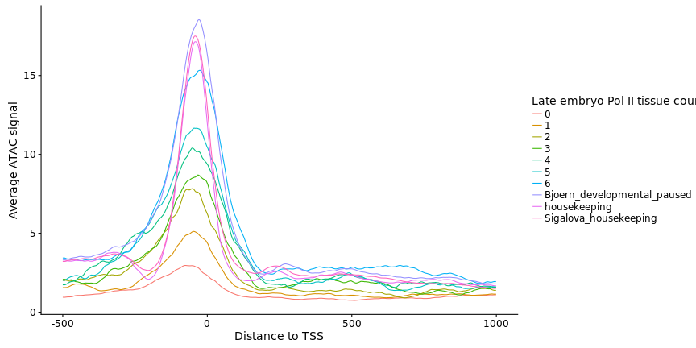

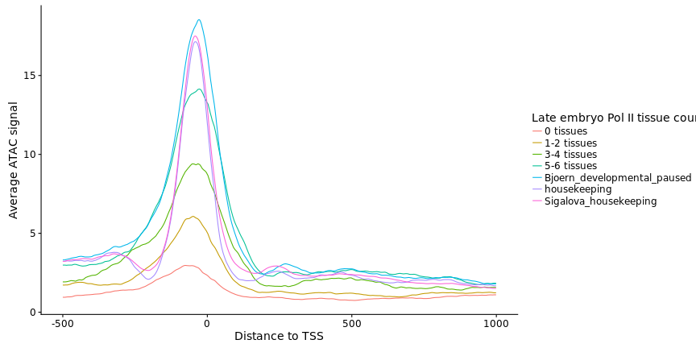

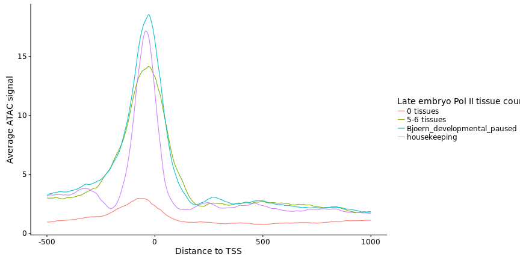

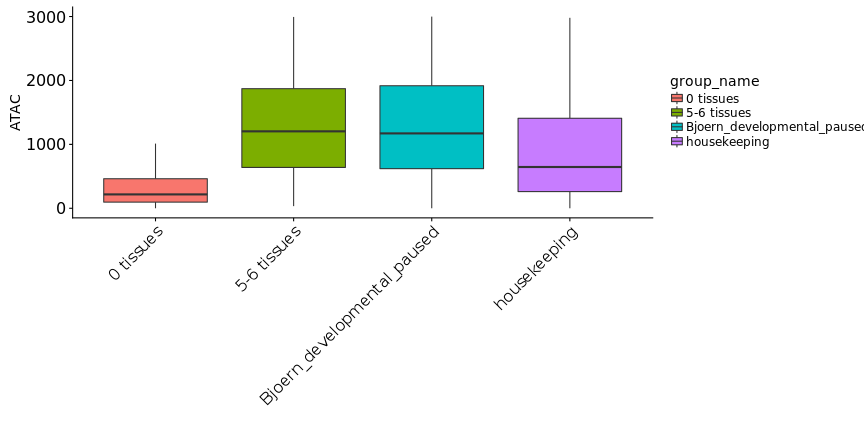

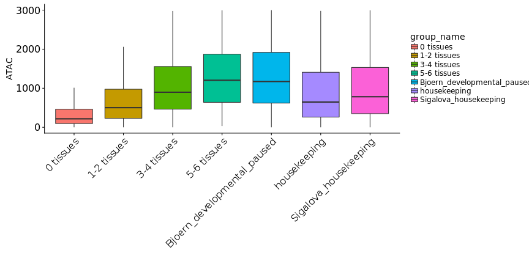

```
##
##  Wilcoxon rank sum test with continuity correction
##
## data:  filter(., group_name == test_group_1) %>% dplyr::select(variable) %>%  and filter(., group_name == test_group_2) %>% dplyr::select(variable) %>%     as.matrix and     as.matrix
## W = 21568, p-value < 2.2e-16
## alternative hypothesis: true location shift is not equal to 0
```

```
##
##  Wilcoxon rank sum test with continuity correction
##
## data:  filter(., group_name == test_group_1) %>% dplyr::select(variable) %>%  and filter(., group_name == test_group_2) %>% dplyr::select(variable) %>%     as.matrix and     as.matrix
## W = 21224, p-value < 2.2e-16
## alternative hypothesis: true location shift is not equal to 0
```

```
##
##  Wilcoxon rank sum test with continuity correction
##
## data:  filter(., group_name == test_group_1) %>% dplyr::select(variable) %>%  and filter(., group_name == test_group_2) %>% dplyr::select(variable) %>%     as.matrix and     as.matrix
## W = 66473, p-value < 2.2e-16
## alternative hypothesis: true location shift is not equal to 0
```

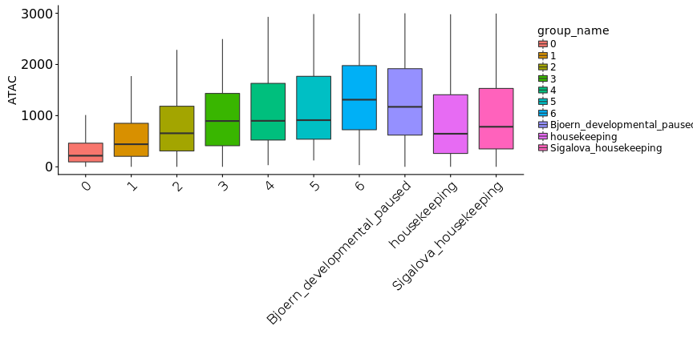

## MNase 2-4h and 14-17hrs

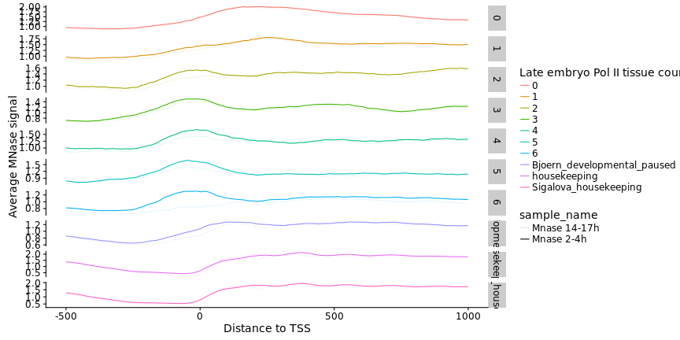

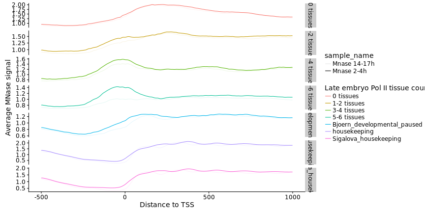

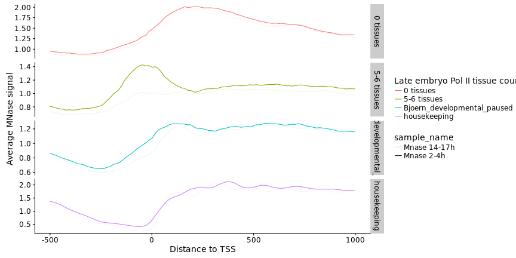

## Tissue specific ATAC signals

label window_upstream window_downstream ip

epidermis 150 0 Epidermis_7021_INTACT_14_17h_ATAC_1.bam_from0to100_rpm.bw

```
gut            150                 0                Gut_INTACT_14_17h_ATAC_1.bam_from0to100_rpm.bw
```

muscle 150 0 Muscle_mef2_INTACT_14_17h_ATAC_1.bam_from0to100_rpm.bw